# **Regularization in Neural Networks**

In deep learning, overfitting occurs when a model learns the training data too well and struggles to perform effectively on new, unseen inputs. Regularization addresses this by simplifying the model or reducing its sensitivity to particular training instances. Two regularization techniques, Dropout and MC-Dropout, assist the model in generalizing more effectively by minimizing reliance on individual neurons or pathways during the training process.

**Dropout**

**Intuition**

Imagine you're preparing for an exam with a group of friends, but each day, one or two students are missing. This forces everyone to understand the topics well themselves instead of always depending on the smartest person in the group. Dropout in neural networks works in a similar way. During training, it randomly turns off some of the neurons in a layer. This stops the network from relying too much on any single neuron.

As a result, every time the model sees the data, its internal structure looks a bit different. This randomness helps the model become more flexible and prevents it from simply memorizing the training data. Instead, it learns to recognize patterns in a way that makes it perform better on new, unseen data. In short, Dropout makes the model stronger and more reliable just like every student getting better at studying on their own.

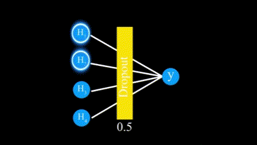

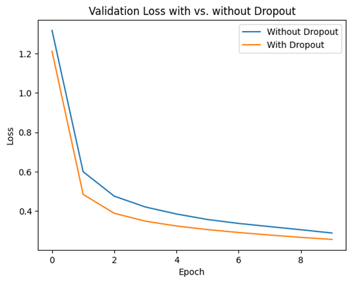

**Mathematics**

In dropout, some neurons in a layer are randomly turned off during training to prevent the model from depending too much on specific neurons.

Keywords:

- h = activations of the layer before dropout
- r = a mask made of 0s and 1s, where 1 means keep the neuron and 0 means drop it.
- new_h = the final output after applying dropout and scaling
- p = probability of neurons to keep

Eg.

h = [1.2, 0.5, 0.7, 0.9]

r = [1, 0, 1, 0]

p = 0.5

new_h = [1.2, 0.5, 0.7, 0.9] * [1, 0, 1, 0] / 0.5

= [2.4, 0, 1.4, 0]

We turned off the 2nd and 4th neurons. The ones that stayed on were divided by probability to keep the total output at a similar level. This helps the model learn better by not relying too much on any one neuron. Next time there will be a different random r for the next iteration.

**Problems**

• The training process becomes noisy: Randomness induces fluctuations throughout training.

•Requires careful adjustment: Excessive dropout (e.g., 0.7) can weaken the model, while minimal dropout may not provide benefits.

•Does not estimate uncertainty: After training, the model produces fixed predictions without a measure of confidence.

**Small Usage**

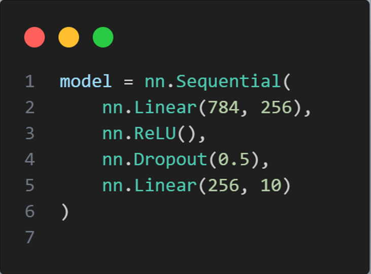

**Monte Carlo Dropout (MC-Dropout)**

**Intuition**

MC-Dropout builds upon the idea of regular Dropout. In a typical neural network, dropout is only active during training. But in MC-Dropout, dropout remains active even during testing. This means that for the same input, the model gives slightly different outputs each time because different neurons are randomly dropped on every forward pass.

Think of it like asking the same question to a group of people in slightly different settings—maybe the lighting changes, or some people are distracted. Each time, the answers vary a little. If you take the average of all their answers, you get a more reliable overall response. And the spread of their answers tells you how confident the group is.

This is exactly what MC-Dropout does: it gives not just a prediction, but also a sense of how confident the model is about that prediction.

[figure not shown]

**Mathematics**

To check how confident the model is, we calculate how much these predictions vary from the average. This is done using standard deviation:

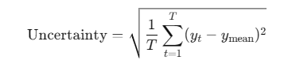

If the predictions are close to each other, the uncertainty is low, meaning the model is confident. If the predictions are spread out, the uncertainty is high, meaning the model is not very sure.

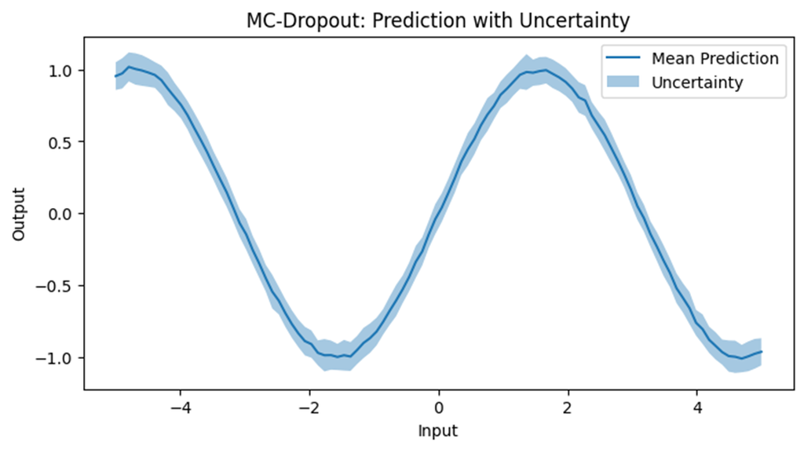

**Problems**

- Slower predictions: Since you need multiple forward passes, inference takes longer.
- Rough estimate of uncertainty: It's not as precise as true Bayesian methods.
- Computationally expensive: Running many passes, especially on large models, increases cost.